# My Visual Data Story

## Introduction

This is a Stats220 project with the idea of representing something I noticed when I was commuting to/from university every day ~ that almost everyone was on their phone, every single time, so we started logging data for Project 2 of this course, and later Project 4. Obervations were made at the New Lynn, Avondale, Parnell and Grafton train stations, by myself and later 2 others.

## Data Collection

The data was collected over a period of around 2 and a half weeks, however these weeks were not a single period of time, and about a month separated some of the observations, we made note how many people were at the train station with us, how many we could see were using their phones, and in the second half of data collection, we started logging how many people at the train station looked elderly, to try to see if the phone users were primarily the younger generation. We also recorded the day, and the date and time was automatically logged. In total, 536 people were observed across 39 logged entries.18 of the 39 were used to do a test on whether elderly people tend to use their phones at the train stations, as the older observations didn’t include the question about how many older people were there with them.

## Entries per Day

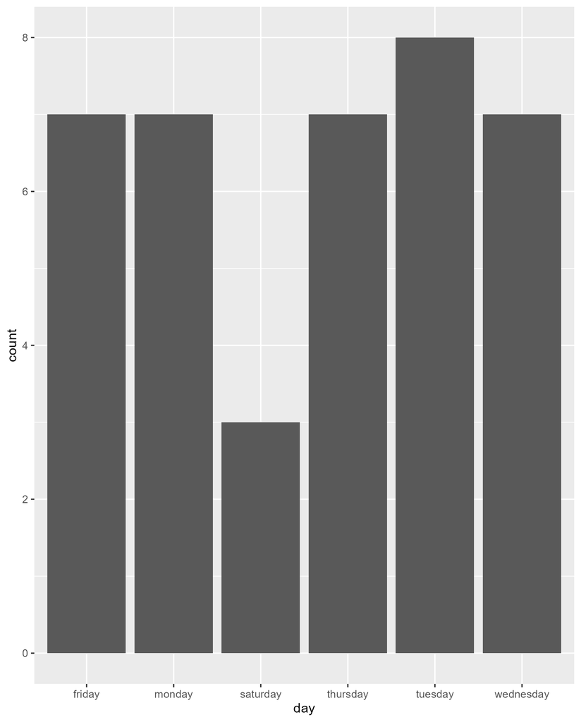

Entries per Day

This bar chart is a visual representation of the amount of observations were made, and what day each was made, a relatively similar amount of observations were made across all of the weekdays, with Tuesday having one more observation than the rest. Hardly any observations were logged in the weekend, with the weekends not being logged much due to us hardly going into the city in the weekends.

## Demographics and Phone Use

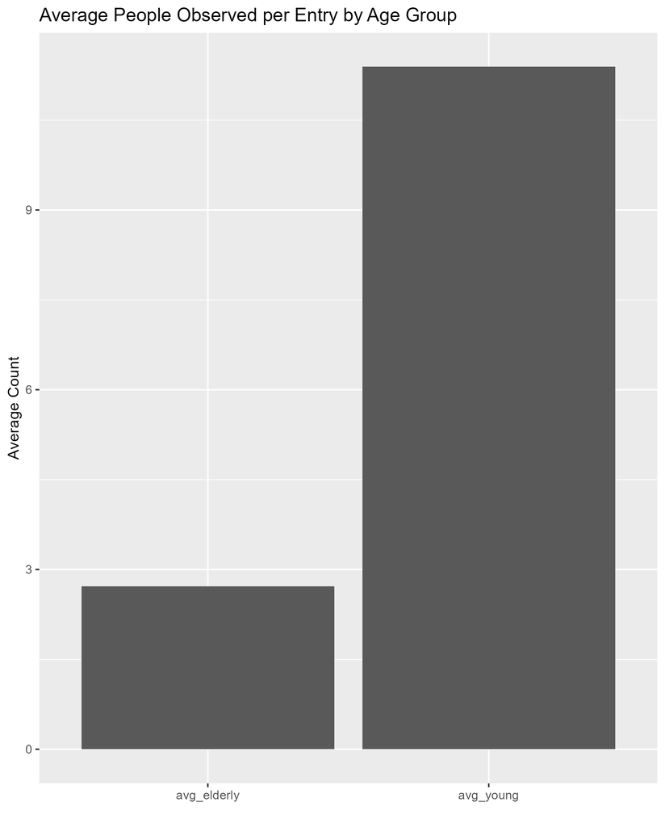

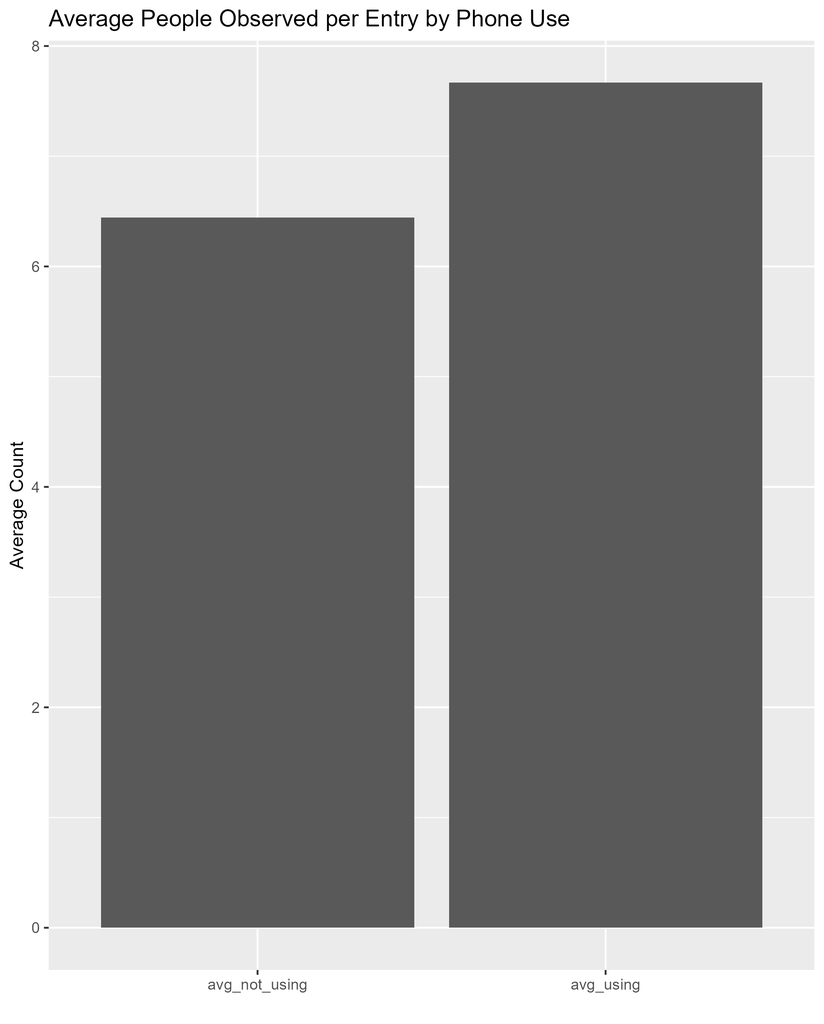

The graph on the left represents the average amount of young people against the average amount of elderly people observed at each log taken in the second half of the logging, wheras the right just looks at whether/not people were using their phones at the train station, with the average people using their phone/not on the same dataset.

These graphs show a glimpse of a link that younger people are the people who are always on their phones, however the average using/not using graph is a lot closer than I thought, I initially thought the relations would look similar, or exactly the same.

Recently I noticed that a lot of the youthful people at the trainstation werent actively holding their phones, but just had their airpods in. This made me realize that this should have been considered in my logging, so if I were to do this again, I would include this as another value, and I would then expect to see a much more noticable trend.

## Weekends vs Weekdays

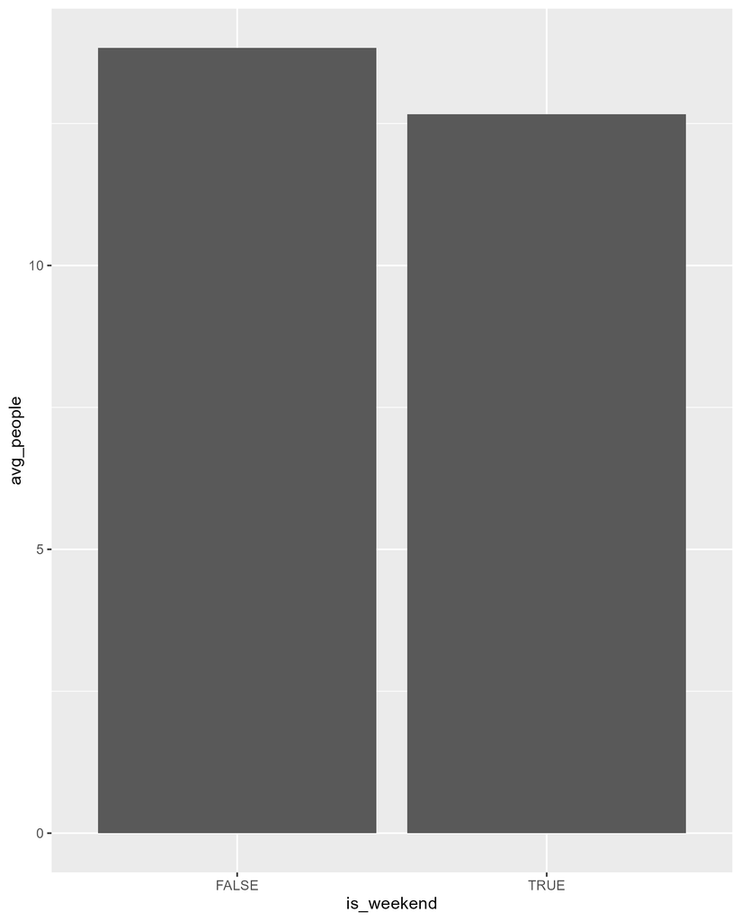

Weekends vs Weekdays

## Summary

Overall, this experiment did not give me the overwhelming relationship I had thought it would. However, after reflection - I should have seen it coming, because I didnt consider people who just listen to music, I usually sit and watch Netflix while I wait so I didnt consider it. I would be interested to look into what the data would look like if I had logged airpods users as well in the future.